# R Notebook

```r
library(dplyr)
library(stringr)
library(tidyr)
library(glmnet)
library(lmtest)
```

```r
library(corrplot)
```

## Reading and Cleaning the Data set

```r
cars_raw<- read.csv("used_cars_data.csv",stringsAsFactors = FALSE)
dim(cars_raw)
```

```
## [1] 7253   14
```

```r
names(cars_raw)
```

```
##  [1] "S.No."             "Name"              "Location"
##  [4] "Year"              "Kilometers_Driven" "Fuel_Type"
##  [7] "Transmission"      "Owner_Type"        "Mileage"
## [10] "Engine"            "Power"             "Seats"
## [13] "New_Price"         "Price"
```

```r
str(cars_raw)
```

```
## 'data.frame':    7253 obs. of  14 variables:
##  $ S.No.            : int  0 1 2 3 4 5 6 7 8 9 ...
##  $ Name             : chr  "Maruti Wagon R LXI CNG" "Hyundai Creta 1.6 CRDi SX Option" "Honda Jazz V" "Maruti Ertiga VDI" ...
##  $ Location         : chr  "Mumbai" "Pune" "Chennai" "Chennai" ...
##  $ Year             : int  2010 2015 2011 2012 2013 2012 2013 2016 2013 2012 ...
##  $ Kilometers_Driven: int  72000 41000 46000 87000 40670 75000 86999 36000 64430 65932 ...
##  $ Fuel_Type        : chr  "CNG" "Diesel" "Petrol" "Diesel" ...
##  $ Transmission     : chr  "Manual" "Manual" "Manual" "Manual" ...
##  $ Owner_Type       : chr  "First" "First" "First" "First" ...
##  $ Mileage          : chr  "26.6 km/kg" "19.67 kmpl" "18.2 kmpl" "20.77 kmpl" ...
##  $ Engine           : chr  "998 CC" "1582 CC" "1199 CC" "1248 CC" ...
##  $ Power            : chr  "58.16 bhp" "126.2 bhp" "88.7 bhp" "88.76 bhp" ...
##  $ Seats            : int  5 5 5 7 5 5 5 8 5 5 ...
##  $ New_Price        : chr  "" "" "8.61 Lakh" "" ...
##  $ Price            : num  1.75 12.5 4.5 6 17.74 ...
```

```r
summary(cars_raw)
```

```
##      S.No.          Name             Location              Year
##  Min.   :   0   Length:7253        Length:7253        Min.   :1996
##  1st Qu.:1813   Class :character   Class :character   1st Qu.:2011
##  Median :3626   Mode  :character   Mode  :character   Median :2014
##  Mean   :3626                                         Mean   :2013
##  3rd Qu.:5439                                         3rd Qu.:2016
##  Max.   :7252                                         Max.   :2019
##
##  Kilometers_Driven  Fuel_Type         Transmission        Owner_Type
##  Min.   :    171   Length:7253        Length:7253        Length:7253
##  1st Qu.:  34000   Class :character   Class :character   Class :character
##  Median :  53416   Mode  :character   Mode  :character   Mode  :character
##  Mean   :  58699
##  3rd Qu.:  73000
##  Max.   :6500000
##
##    Mileage             Engine             Power               Seats
##  Length:7253        Length:7253        Length:7253        Min.   : 0.00
##  Class :character   Class :character   Class :character   1st Qu.: 5.00
##  Mode  :character   Mode  :character   Mode  :character   Median : 5.00
##                                                           Mean   : 5.28
##                                                           3rd Qu.: 5.00
##                                                           Max.   :10.00
##                                                           NA's   :53
##   New_Price             Price
##  Length:7253        Min.   :  0.440
##  Class :character   1st Qu.:  3.500
##  Mode  :character   Median :  5.640
##                     Mean   :  9.479
##                     3rd Qu.:  9.950
##                     Max.   :160.000
##                     NA's   :1234
```

```r
#drops ID since its useless
#will also not consider New price since over 70% of NewPrice col is empty
cars<- cars_raw %>% select(-S.No.,-New_Price)
#converting the currency from INR Lakhs to USD
cars <- cars %>% mutate(Price = 1120*Price)

#Stripping the unit from these variables' values so they can be quantifiable
cars<-cars  %>% mutate(Mileage = as.numeric(str_extract(Mileage, "[0-9.]+")))
cars<-cars  %>% mutate(Engine = as.numeric(str_extract(Engine, "[0-9.]+")))
cars<-cars  %>% mutate(Power = as.numeric(str_extract(Power,"[0-9.]+")))
```

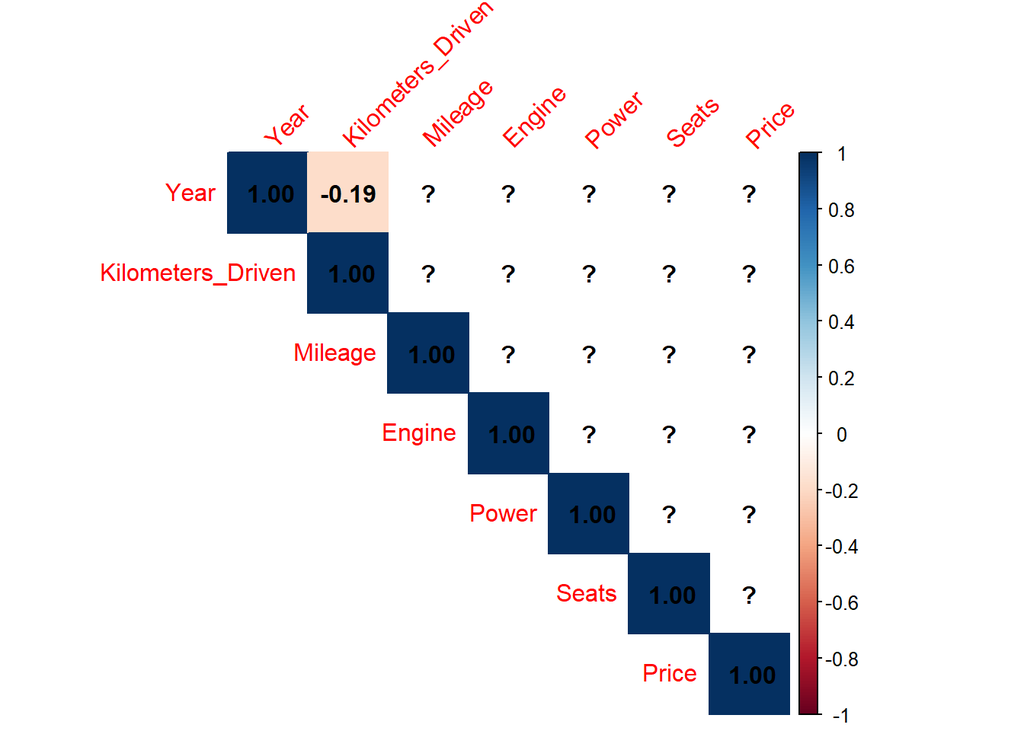

```r
num_cars <- cars %>% select_if(is.numeric)
corr_matrix<-cor(num_cars)
corrplot(corr_matrix, method="color", type="upper",addCoef.col = "black", tl.srt = 45)
```

```r
#make sure there are no more missing values
colSums(is.na(cars))
```

```
##              Name          Location              Year Kilometers_Driven
##                 0                 0                 0                 0
##         Fuel_Type      Transmission        Owner_Type           Mileage
##                 0                 0                 0                 2
##            Engine             Power             Seats             Price
##                46               175                53              1234
```

```r
cars <- na.omit(cars)
```

## Regularization + Transformations

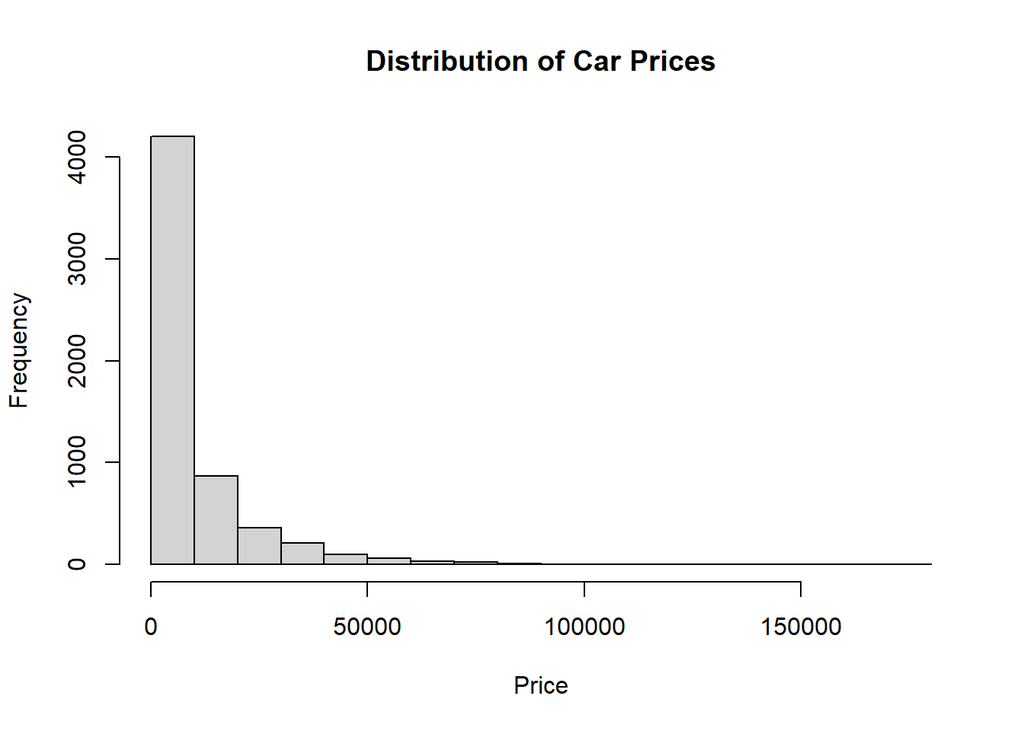

```r
hist(cars$Price, xlab="Price", main="Distribution of Car Prices")
```

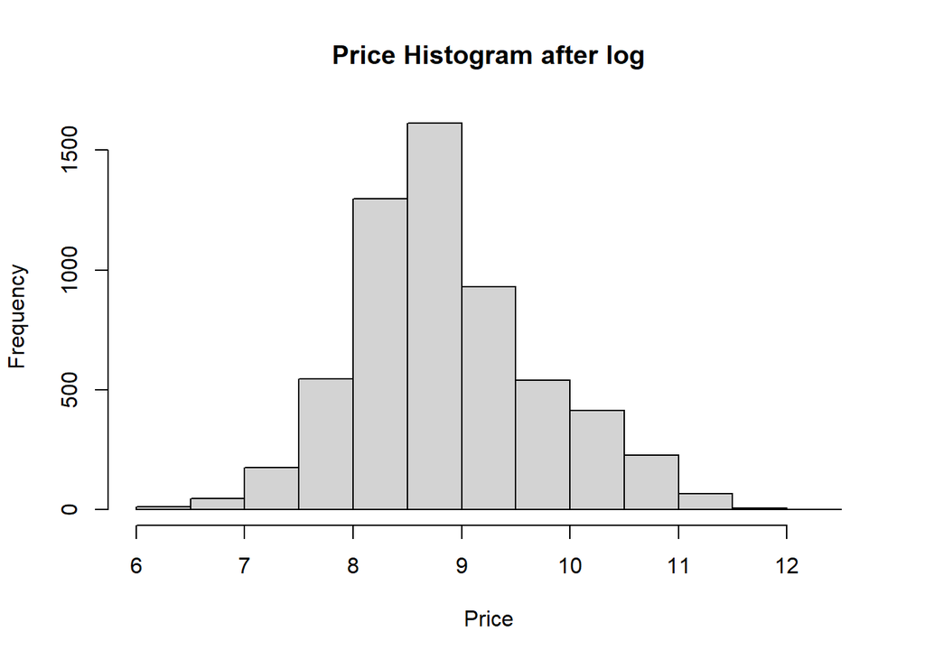

```r
hist(log(cars$Price), xlab="Price", main="Price Histogram after log")
```

```r
#Since the plot is very rightly skewed, we should apply log to normalize it
```

```r
#Want to make sure that we do not include the variables name and location to prevent the creation of dummy variables to be created
cars_no_name_location <- cars %>% select(-Name,-Location)
ols_model <- lm(log(cars$Price)~., data=cars_no_name_location)
summary(ols_model)
```

```
##
## Call:
## lm(formula = log(cars$Price) ~ ., data = cars_no_name_location)
##
## Residuals:
##     Min      1Q  Median      3Q     Max
## -3.8957 -0.1820  0.0159  0.1980  1.5711
##
## Coefficients:
##                            Estimate Std. Error t value Pr(>|t|)
## (Intercept)              -2.476e+02  3.030e+00 -81.714  < 2e-16 ***
## Year                      1.271e-01  1.511e-03  84.108  < 2e-16 ***
## Kilometers_Driven        -6.649e-08  4.487e-08  -1.482  0.13847
## Fuel_TypeDiesel           2.102e-01  4.257e-02   4.939 8.08e-07 ***
## Fuel_TypeLPG              1.270e-02  1.067e-01   0.119  0.90529
## Fuel_TypePetrol          -1.327e-01  4.334e-02  -3.062  0.00221 **
## TransmissionManual       -3.191e-01  1.209e-02 -26.394  < 2e-16 ***
## Owner_TypeFourth & Above  5.720e-02  1.173e-01   0.488  0.62575
## Owner_TypeSecond         -5.594e-02  1.171e-02  -4.776 1.83e-06 ***
## Owner_TypeThird          -1.336e-01  3.213e-02  -4.157 3.27e-05 ***
## Mileage                  -2.140e-02  1.591e-03 -13.453  < 2e-16 ***
## Engine                    8.880e-05  2.025e-05   4.386 1.18e-05 ***
## Power                     7.810e-03  1.961e-04  39.832  < 2e-16 ***
## Seats                     6.913e-03  6.841e-03   1.011  0.31226
## ---
## Signif. codes:  0 '***' 0.001 '**' 0.01 '*' 0.05 '.' 0.1 ' ' 1
##
## Residual standard error: 0.309 on 5858 degrees of freedom
## Multiple R-squared:  0.8724, Adjusted R-squared:  0.8721
## F-statistic:  3081 on 13 and 5858 DF,  p-value: < 2.2e-16
```

# Checking for Assumptions

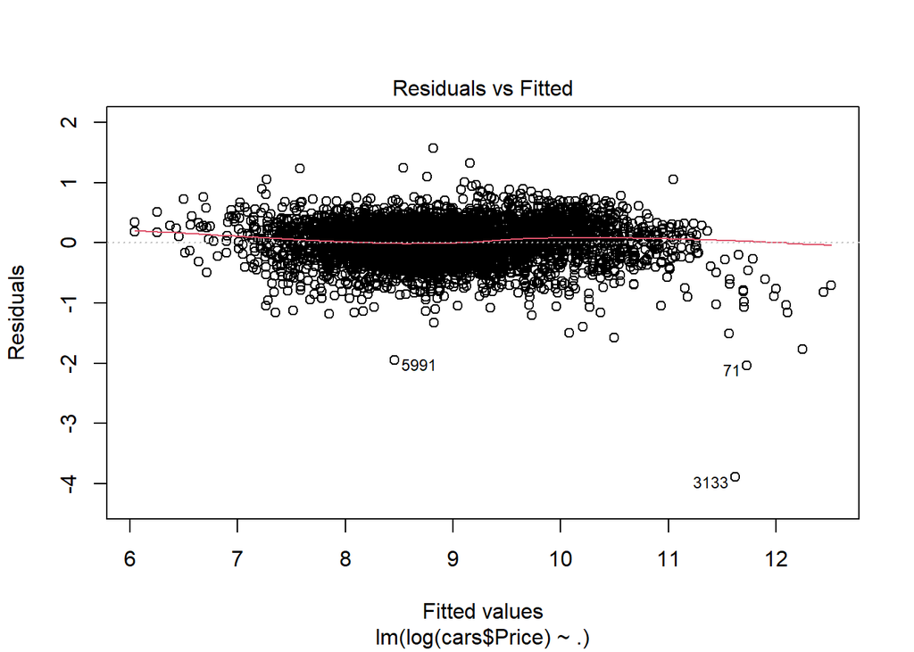

```r
plot(ols_model,which = 1)
```

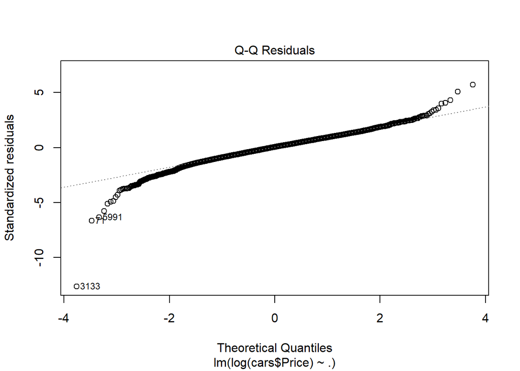

```r
plot(ols_model,which = 2)
```

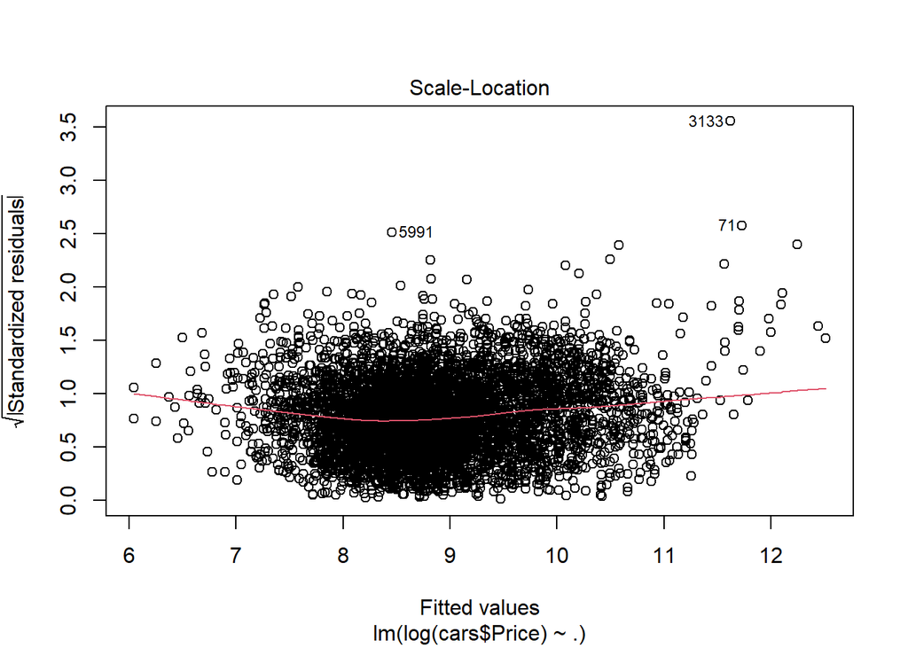

```r
plot(ols_model,which = 3)
```

```r
bptest(ols_model)
```

```
##
##  studentized Breusch-Pagan test
##
## data:  ols_model
## BP = 266.18, df = 13, p-value < 2.2e-16
```

# Residual vs fitted plot does not really show any strong curvature, this plot indicates that the relationship between log(Prices) and the predictors is reasonably Linear.

# Q-Q Plot indicates the central portion is normal. The tails however deviate noticeably due to several large residuals at the end. Due to the large sample size, I do not think that this violation is severe enough to invalidate the model.

# According to the B-P test, there is some heteroscedasticity present. Given that our sample size is large (over 5,000 observations), the BP test can be extremely sensitive. This makes me believe it should not be so severe to invalidate it for that reason. If we also look at the Residual vs fitted plot, we can see that there is only mild heteroscedasticity if not minor.

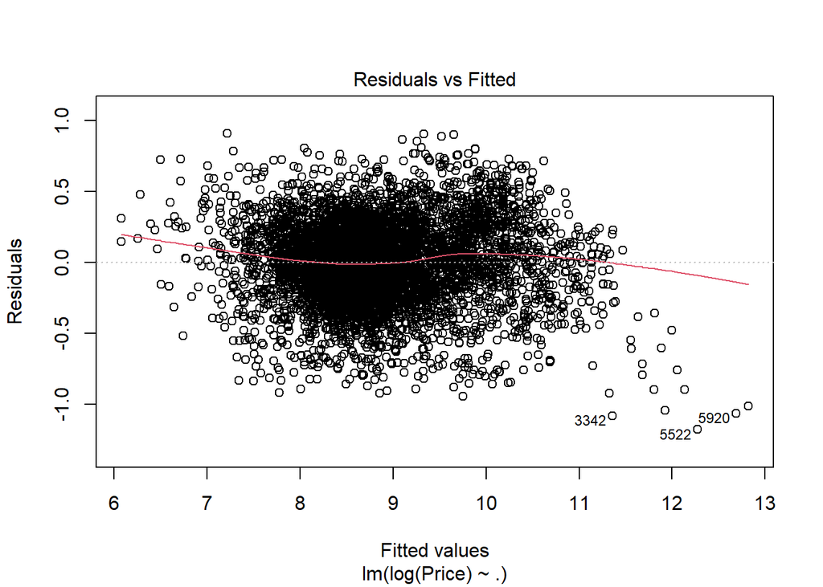

```r
ols_res <- rstandard(ols_model)
outliers <- which(abs(ols_res) > 3)

cars_clean <- cars_no_name_location[-outliers, ]
ols_clean <- lm(log(Price) ~ ., data = cars_clean)

plot(ols_clean, which = 1)
```

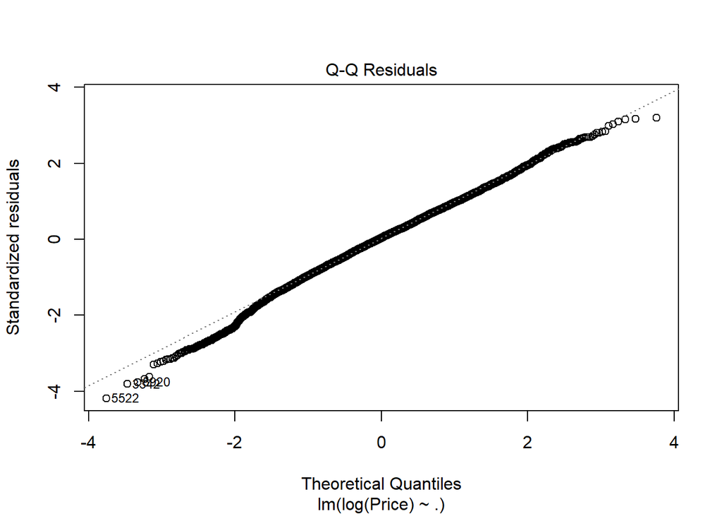

```r
plot(ols_clean, which = 2)
```

```r
bptest(ols_clean)
```

```
##
##  studentized Breusch-Pagan test
##
## data:  ols_clean
## BP = 500.88, df = 13, p-value < 2.2e-16
```

# Trying to get rid of the outliers to deal with the homoskedasticity seems to make it worst so we will just keep it the way it is

## Perform OLS and Lasso

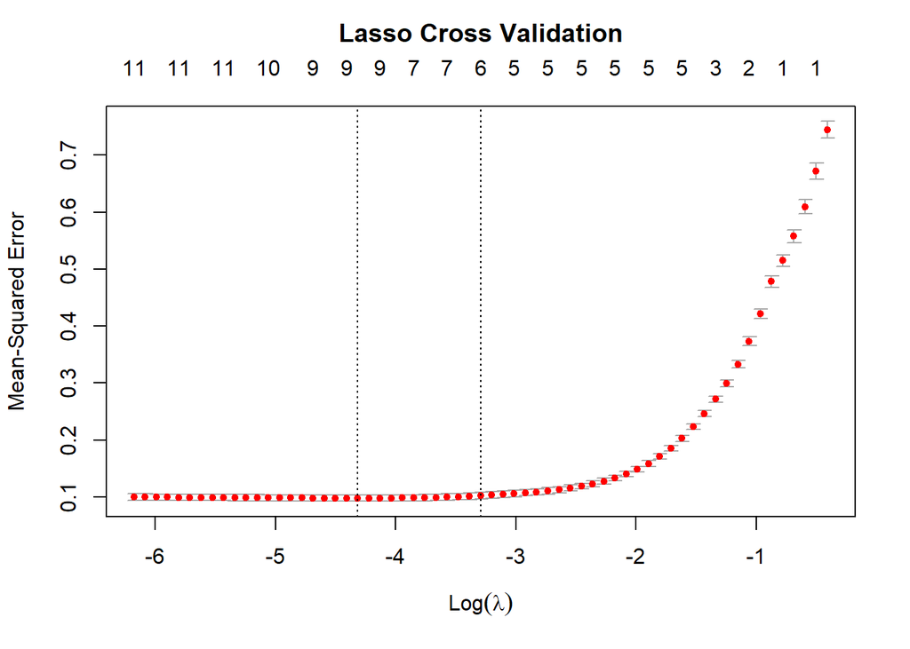

```r
x <- model.matrix(log(Price)~., data=cars_no_name_location)[,-1]
y <- log(cars_no_name_location$Price)
#x <- model.matrix(Price~., data=cars_clean)[,-1]
#y <- cars_clean$Price

set.seed(1)
#Lasso:
cv_lasso <-cv.glmnet(x,y, alpha=1)
plot(cv_lasso)
title("Lasso Cross Validation", line = 2.5)
```

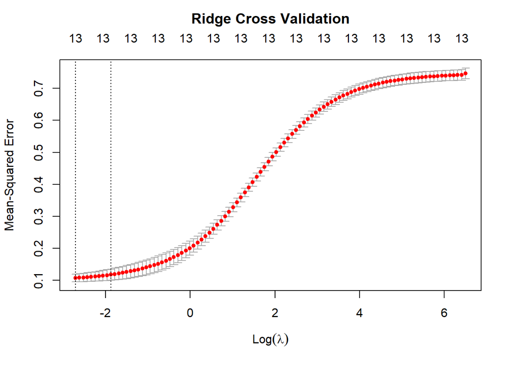

```r
#Best Lambda
lasso_lambda <- cv_lasso$lambda.min
#coefficients at Lambda.min
lasso_coefs <- coef(cv_lasso, s= lasso_lambda)



#Ridge:
cv_ridge <- cv.glmnet(x,y, alpha=0)
plot(cv_ridge)
title("Ridge Cross Validation", line = 2.5)
```

```r
#Best Lambda
ridge_lambda <- cv_ridge$lambda.min
#coefficients at Lambda.min
ridge_coefs <- coef(cv_ridge, s= ridge_lambda)
```

```r
coef_df<- data.frame(variable = rownames(lasso_coefs), coefficient=as.numeric(lasso_coefs))
coef_df %>% filter (coefficient!=0) %>% arrange(desc(abs(coefficient)))
```

| variable | coefficient |
| --- | --- |
| (Intercept) | -2.419554e+02 |
| TransmissionManual | -3.072828e-01 |
| Fuel_TypeDiesel | 2.314113e-01 |
| Year | 1.242376e-01 |
| Fuel_TypePetrol | -6.973794e-02 |
| Owner_TypeThird | -3.866434e-02 |
| Owner_TypeSecond | -2.024131e-02 |
| Mileage | -1.494068e-02 |
| Power | 7.586494e-03 |
| Engine | 1.325896e-04 |